# Creating helper functions

# making predictions

## 10 Create a training/test split for your data.

```python
from sklearn.model_selection import train_test_split
```

```python
# every 5th observation from the original dataset to be the test
test=df.iloc[0:506:5]
```

```python
# exclude test (subset of dataframe) to get train
train = df.merge(test, how='left', indicator=True)
train = train[train['_merge'] == 'left_only']
train=train.drop(['_merge'],axis=1)
# the number of the observations in respective data
print(test.shape,train.shape)
```

```
(102, 15) (404, 15)
```

```python
# the respective target variable
print(test.highPriced,train.highPriced)
```

```
0      False
5      False
10     False
15     False
20     False
       ...
485    False
490    False
495    False
500    False
505    False
Name: highPriced, Length: 102, dtype: bool 1      False
2      False
3      False
4       True
6      False
       ...
499    False
501    False
502    False
503    False
504    False
Name: highPriced, Length: 404, dtype: bool
```

## 11. Create a baseline set of predictions.

```python
import random
```

```python
random.seed(1000)
#pred=train.sample(102).highPriced
pred=test.assign(highPriced=train.sample(102).highPriced.values)
pred
```

|  | CRIM | ZN | INDUS | CHAS | NOX | RM | AGE | DIS | RAD | TAX | PTRATIO | B | LSTAT | MEDV | highPriced |
| --- | --- | --- | --- | --- | --- | --- | --- | --- | --- | --- | --- | --- | --- | --- | --- |
| 0 | 0.00632 | 18.0 | 2.31 | 0.0 | 0.538 | 6.575 | 65.2 | 4.0900 | 1.0 | 296.0 | 15.3 | 396.90 | 4.98 | 24.0 | False |
| 5 | 0.02985 | 0.0 | 2.18 | 0.0 | 0.458 | 6.430 | 58.7 | 6.0622 | 3.0 | 222.0 | 18.7 | 394.12 | 5.21 | 28.7 | False |
| 10 | 0.22489 | 12.5 | 7.87 | 0.0 | 0.524 | 6.377 | 94.3 | 6.3467 | 5.0 | 311.0 | 15.2 | 392.52 | 20.45 | 15.0 | False |
| 15 | 0.62739 | 0.0 | 8.14 | 0.0 | 0.538 | 5.834 | 56.5 | 4.4986 | 4.0 | 307.0 | 21.0 | 395.62 | 8.47 | 19.9 | False |
| 20 | 1.25179 | 0.0 | 8.14 | 0.0 | 0.538 | 5.570 | 98.1 | 3.7979 | 4.0 | 307.0 | 21.0 | 376.57 | 21.02 | 13.6 | False |
| ... | ... | ... | ... | ... | ... | ... | ... | ... | ... | ... | ... | ... | ... | ... | ... |
| 485 | 3.67367 | 0.0 | 18.10 | 0.0 | 0.583 | 6.312 | 51.9 | 3.9917 | 24.0 | 666.0 | 20.2 | 388.62 | 10.58 | 21.2 | False |
| 490 | 0.20746 | 0.0 | 27.74 | 0.0 | 0.609 | 5.093 | 98.0 | 1.8226 | 4.0 | 711.0 | 20.1 | 318.43 | 29.68 | 8.1 | False |
| 495 | 0.17899 | 0.0 | 9.69 | 0.0 | 0.585 | 5.670 | 28.8 | 2.7986 | 6.0 | 391.0 | 19.2 | 393.29 | 17.60 | 23.1 | False |
| 500 | 0.22438 | 0.0 | 9.69 | 0.0 | 0.585 | 6.027 | 79.7 | 2.4982 | 6.0 | 391.0 | 19.2 | 396.90 | 14.33 | 16.8 | False |
| 505 | 0.04741 | 0.0 | 11.93 | 0.0 | 0.573 | 6.030 | 80.8 | 2.5050 | 1.0 | 273.0 | 21.0 | 396.90 | 7.88 | 11.9 | False |

102 rows × 15 columns

```python
from sklearn.metrics import confusion_matrix
from sklearn.metrics import accuracy_score
from sklearn.metrics import classification_report
```

```python
print("the accuracy score is ",accuracy_score(test.highPriced,pred.highPriced))
print(classification_report(test.highPriced,pred.highPriced))
```

```
the accuracy score is  0.8627450980392157
              precision    recall  f1-score   support

       False       0.95      0.91      0.92        95
        True       0.18      0.29      0.22         7

    accuracy                           0.86       102
   macro avg       0.56      0.60      0.57       102
weighted avg       0.89      0.86      0.88       102
```

```python
# find the rows that are different
diff=pd.concat([test,pred]).drop_duplicates(keep=False)
print(diff.shape)
diff
```

```
(28, 15)
```

|  | CRIM | ZN | INDUS | CHAS | NOX | RM | AGE | DIS | RAD | TAX | PTRATIO | B | LSTAT | MEDV | highPriced |
| --- | --- | --- | --- | --- | --- | --- | --- | --- | --- | --- | --- | --- | --- | --- | --- |
| 25 | 0.84054 | 0.0 | 8.14 | 0.0 | 0.538 | 5.599 | 85.7 | 4.4546 | 4.0 | 307.0 | 21.0 | 303.42 | 16.51 | 13.9 | False |
| 55 | 0.01311 | 90.0 | 1.22 | 0.0 | 0.403 | 7.249 | 21.9 | 8.6966 | 5.0 | 226.0 | 17.9 | 395.93 | 4.81 | 35.4 | True |
| 160 | 1.27346 | 0.0 | 19.58 | 1.0 | 0.605 | 6.250 | 92.6 | 1.7984 | 5.0 | 403.0 | 14.7 | 338.92 | 5.50 | 27.0 | False |
| 180 | 0.06588 | 0.0 | 2.46 | 0.0 | 0.488 | 7.765 | 83.3 | 2.7410 | 3.0 | 193.0 | 17.8 | 395.56 | 7.56 | 39.8 | True |
| 190 | 0.09068 | 45.0 | 3.44 | 0.0 | 0.437 | 6.951 | 21.5 | 6.4798 | 5.0 | 398.0 | 15.2 | 377.68 | 5.10 | 37.0 | True |
| 205 | 0.13642 | 0.0 | 10.59 | 0.0 | 0.489 | 5.891 | 22.3 | 3.9454 | 4.0 | 277.0 | 18.6 | 396.90 | 10.87 | 22.6 | False |
| 225 | 0.52693 | 0.0 | 6.20 | 0.0 | 0.504 | 8.725 | 83.0 | 2.8944 | 8.0 | 307.0 | 17.4 | 382.00 | 4.63 | 50.0 | True |
| 250 | 0.14030 | 22.0 | 5.86 | 0.0 | 0.431 | 6.487 | 13.0 | 7.3967 | 7.0 | 330.0 | 19.1 | 396.28 | 5.90 | 24.4 | False |
| 270 | 0.29916 | 20.0 | 6.96 | 0.0 | 0.464 | 5.856 | 42.1 | 4.4290 | 3.0 | 223.0 | 18.6 | 388.65 | 13.00 | 21.1 | False |
| 300 | 0.04417 | 70.0 | 2.24 | 0.0 | 0.400 | 6.871 | 47.4 | 7.8278 | 5.0 | 358.0 | 14.8 | 390.86 | 6.07 | 24.8 | False |
| 320 | 0.16760 | 0.0 | 7.38 | 0.0 | 0.493 | 6.426 | 52.3 | 4.5404 | 5.0 | 287.0 | 19.6 | 396.90 | 7.20 | 23.8 | False |
| 325 | 0.19186 | 0.0 | 7.38 | 0.0 | 0.493 | 6.431 | 14.7 | 5.4159 | 5.0 | 287.0 | 19.6 | 393.68 | 5.08 | 24.6 | False |
| 355 | 0.10659 | 80.0 | 1.91 | 0.0 | 0.413 | 5.936 | 19.5 | 10.5857 | 4.0 | 334.0 | 22.0 | 376.04 | 5.57 | 20.6 | False |
| 370 | 6.53876 | 0.0 | 18.10 | 1.0 | 0.631 | 7.016 | 97.5 | 1.2024 | 24.0 | 666.0 | 20.2 | 392.05 | 2.96 | 50.0 | True |
| 25 | 0.84054 | 0.0 | 8.14 | 0.0 | 0.538 | 5.599 | 85.7 | 4.4546 | 4.0 | 307.0 | 21.0 | 303.42 | 16.51 | 13.9 | True |
| 55 | 0.01311 | 90.0 | 1.22 | 0.0 | 0.403 | 7.249 | 21.9 | 8.6966 | 5.0 | 226.0 | 17.9 | 395.93 | 4.81 | 35.4 | False |
| 160 | 1.27346 | 0.0 | 19.58 | 1.0 | 0.605 | 6.250 | 92.6 | 1.7984 | 5.0 | 403.0 | 14.7 | 338.92 | 5.50 | 27.0 | True |
| 180 | 0.06588 | 0.0 | 2.46 | 0.0 | 0.488 | 7.765 | 83.3 | 2.7410 | 3.0 | 193.0 | 17.8 | 395.56 | 7.56 | 39.8 | False |
| 190 | 0.09068 | 45.0 | 3.44 | 0.0 | 0.437 | 6.951 | 21.5 | 6.4798 | 5.0 | 398.0 | 15.2 | 377.68 | 5.10 | 37.0 | False |
| 205 | 0.13642 | 0.0 | 10.59 | 0.0 | 0.489 | 5.891 | 22.3 | 3.9454 | 4.0 | 277.0 | 18.6 | 396.90 | 10.87 | 22.6 | True |
| 225 | 0.52693 | 0.0 | 6.20 | 0.0 | 0.504 | 8.725 | 83.0 | 2.8944 | 8.0 | 307.0 | 17.4 | 382.00 | 4.63 | 50.0 | False |
| 250 | 0.14030 | 22.0 | 5.86 | 0.0 | 0.431 | 6.487 | 13.0 | 7.3967 | 7.0 | 330.0 | 19.1 | 396.28 | 5.90 | 24.4 | True |
| 270 | 0.29916 | 20.0 | 6.96 | 0.0 | 0.464 | 5.856 | 42.1 | 4.4290 | 3.0 | 223.0 | 18.6 | 388.65 | 13.00 | 21.1 | True |
| 300 | 0.04417 | 70.0 | 2.24 | 0.0 | 0.400 | 6.871 | 47.4 | 7.8278 | 5.0 | 358.0 | 14.8 | 390.86 | 6.07 | 24.8 | True |
| 320 | 0.16760 | 0.0 | 7.38 | 0.0 | 0.493 | 6.426 | 52.3 | 4.5404 | 5.0 | 287.0 | 19.6 | 396.90 | 7.20 | 23.8 | True |
| 325 | 0.19186 | 0.0 | 7.38 | 0.0 | 0.493 | 6.431 | 14.7 | 5.4159 | 5.0 | 287.0 | 19.6 | 393.68 | 5.08 | 24.6 | True |
| 355 | 0.10659 | 80.0 | 1.91 | 0.0 | 0.413 | 5.936 | 19.5 | 10.5857 | 4.0 | 334.0 | 22.0 | 376.04 | 5.57 | 20.6 | True |
| 370 | 6.53876 | 0.0 | 18.10 | 1.0 | 0.631 | 7.016 | 97.5 | 1.2024 | 24.0 | 666.0 | 20.2 | 392.05 | 2.96 | 50.0 | False |

## 12. use a 2-level decision tree to make predictions

Re-train a 2-level decision tree (i.e. a tree with 4 leaf nodes) using the training dataset with only the RM and LSTAT variables as inputs.

```python
traintree=train.loc[:,['RM','LSTAT']]
model=clf.fit(traintree,train.highPriced)
Xtest=test.loc[:,['RM','LSTAT']]
ytest=test.highPriced
ypred=model.predict(Xtest)
print("the accuracy score is ",accuracy_score(ytest,ypred))
```

```
the accuracy score is  0.9705882352941176
```

```python
ytest.shape
```

```
(102,)
```

```python
pred=train.sample(102).highPriced
print("the accuracy score is ",accuracy_score(ytest,pred))
```

```
the accuracy score is  0.8823529411764706
```

slightly better than the baseline

# comparing to out-of-the-box classifiers

## 13. Use sklearn’s DecisionTreeClassifier to recreate the decision tree that is trained on the training data.

```
|--- RM <= 7.13
|   |--- LSTAT <= 5.12
|   |   |--- class: False
|   |--- LSTAT >  5.12
|   |   |--- class: False
|--- RM >  7.13
|   |--- RM <= 7.44
|   |   |--- class: False
|   |--- RM >  7.44
|   |   |--- class: True
```

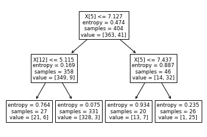

```python
X=train.drop(['MEDV','highPriced'],axis=1)
y=train.highPriced.values
tree3=clf.fit(X,y)
tree.plot_tree(tree3.fit(X,y))
r = export_text(tree3.fit(X,y),feature_names=('CRIM', 'ZN', 'INDUS', 'CHAS', 'NOX', 'RM', 'AGE', 'DIS', 'RAD', 'TAX',
       'PTRATIO', 'B', 'LSTAT'))
print(r)
```

```python
predx=tree3.predict(X)
print("the accuracy score is ",accuracy_score(train.highPriced,predx))
print(classification_report(train.highPriced,predx))
```

```
the accuracy score is  0.9579207920792079
              precision    recall  f1-score   support

       False       0.96      1.00      0.98       363
        True       0.96      0.61      0.75        41

    accuracy                           0.96       404
   macro avg       0.96      0.80      0.86       404
weighted avg       0.96      0.96      0.95       404
```

```
|--- DIS <= 3.95
|   |--- LSTAT <= 6.08
|   |   |--- class: False
|   |--- LSTAT >  6.08
|   |   |--- class: False
|--- DIS >  3.95
|   |--- PTRATIO <= 15.05
|   |   |--- class: True
|   |--- PTRATIO >  15.05
|   |   |--- class: False
```

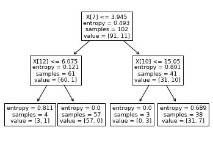

```python
# pred in the baseline
X=pred.drop(['MEDV','highPriced'],axis=1)
y=pred.highPriced.values
tree.plot_tree(clf.fit(X,y))
r = export_text(clf.fit(X,y),feature_names=('CRIM', 'ZN', 'INDUS', 'CHAS', 'NOX', 'RM', 'AGE', 'DIS', 'RAD', 'TAX',
       'PTRATIO', 'B', 'LSTAT'))
print(r)
```

This classifier is almost the same with the train tree above and slightly different with the original one. The tree based on test and random sampling outputs is totally different from this one.

## 14. bagging classifier

```python
from sklearn.ensemble import BaggingClassifier
```

```python
bagclf=BaggingClassifier(base_estimator=clf)
X=train.drop(['MEDV','highPriced'],axis=1)
y=train.highPriced.values
model=bagclf.fit(X,y)
pred=model.predict(test.drop(['MEDV','highPriced'],axis=1))
```

```python
print("the accuracy score is ",accuracy_score(test.highPriced,pred))
print(classification_report(test.highPriced,pred))
```

```
the accuracy score is  0.9705882352941176
              precision    recall  f1-score   support

       False       0.97      1.00      0.98        95
        True       1.00      0.57      0.73         7

    accuracy                           0.97       102
   macro avg       0.98      0.79      0.86       102
weighted avg       0.97      0.97      0.97       102
```

## 15. RandomForestClassifier

```python
from sklearn.ensemble import RandomForestClassifier
```

```python
forestclf=RandomForestClassifier(n_estimators=1,criterion="entropy",max_leaf_nodes=4)
X=train.drop(['MEDV','highPriced'],axis=1)
y=train.highPriced.values
model=forestclf.fit(X,y)
pred=model.predict(test.drop(['MEDV','highPriced'],axis=1))
print("the accuracy score is ",accuracy_score(test.highPriced,pred))
print(classification_report(test.highPriced,pred))
```

```
the accuracy score is  0.9117647058823529
              precision    recall  f1-score   support

       False       0.96      0.95      0.95        95
        True       0.38      0.43      0.40         7

    accuracy                           0.91       102
   macro avg       0.67      0.69      0.68       102
weighted avg       0.92      0.91      0.91       102
```

The random forest classifier perform worse than the models above.